# Compile Decoy Intron Data (overlap first, then bash features)

```r
library(data.table)
library(GenomicRanges)
library(ggplot2)
```

```r
# Upstream of this document (see README "Ordering (v3)"):
#   decoy_exon_overlaps.Rmd Part 1  protein_coding keep -> spliceai_05min_proteincoding.bed
#   split_canonical_exonic.sh       canonical split     -> deep_intronic_splice_sites.bed
#   decoy_exon_overlaps.Rmd Part 2  exon removal        -> deep_intronic_noexon_splice_sites.bed
#   intersect_spliceai_support.sh   CLIP support        -> decoys.bed / cryptic_sites.bed
out_dir <- "../results"
dir.create(out_dir, showWarnings = FALSE, recursive = TRUE)
psi_table <- "../reference/PSI_TABLE-hg38.tab.gz"

# Parts 1-2: supported-cryptic selection.
cryptic_sites_bed <- file.path(out_dir, "cryptic_sites.bed")
canonical_sites_bed <- "../data/Decoys/Canonical_splice_sites.bed"
cryptic_canonical_bed <- file.path(out_dir, "cryptic_canonical_sites.bed")
canonical_supported_bed <- file.path(out_dir, "canonical_supported_sites.bed")
cryptics_supported_bed <- file.path(out_dir, "cryptics_supported.bed")

# Part 3: both classes after the local SpliceAI re-score. The names become the
# site_class column.
splicescores_beds <- c(
  decoy = "../data/Decoys/decoys_splicescores.bed",
  cryptic_supported = "../data/Decoys/cryptics_supported_splicescores.bed"
)

# Minimum LOCAL SpliceAI donor score to retain (applied in Part 3, after load).
# The re-score replaces the whole-intron SpliceAI inference with a LOCAL donor
# score over a 49 nt window centred on each site, so this is NOT comparable to
# the >= 0.05 threshold applied upstream on the raw inference set.
MIN_LOCAL_SPLICEAI <- 0.1

step1_tsv <- file.path(out_dir, "decoy_intron_overlap_step1.tsv")

# Shared by decoys.bed, cryptic_sites.bed, cryptics_supported.bed and their
# re-scored versions.
site_cols <- c(
  "chr", "start", "end", "name", "SpliceAI_score", "strand",
  "rbpnet", "prpf8", "smb", "n_categories"
)
```

## PSI table: HsaIN only, drop `-Q` columns, parse intron coordinates

Loaded once, for Part 1 (cryptic → canonical donor) and Part 3 (intron features).

```r
psi <- fread(psi_table, sep = "\t", header = TRUE)

# Annotated alternative 5' splice sites, removed in Part 3. FullCO lists every
# donor of an Alt5 event: + strand "chr:acceptor-D1+D2,next", - strand
# "chr:D1+D2-acceptor,next".
altd_co <- unique(psi[grepl("^HsaALTD", EVENT), FullCO])
altd_donors <- rbindlist(lapply(strsplit(altd_co, ":", fixed = TRUE), function(x) {
  ends <- strsplit(sub(",.*", "", x[2]), "-", fixed = TRUE)[[1]]
  minus <- grepl("+", ends[1], fixed = TRUE)
  d <- strsplit(if (minus) ends[1] else ends[2], "+", fixed = TRUE)[[1]]
  data.table(chr = x[1], donor = suppressWarnings(as.integer(d)), strand = if (minus) "-" else "+")
}))
altd_donors <- unique(altd_donors[!is.na(donor)])
cat("Annotated alternative 5' splice sites (HsaALTD donors):", nrow(altd_donors), "\n")
```

```
## Annotated alternative 5' splice sites (HsaALTD donors): 133342
```

```r
psi <- psi[grepl("^HsaIN", EVENT)]
q_cols <- grep("-Q$", names(psi), value = TRUE)
if (length(q_cols) > 0) psi[, (q_cols) := NULL]

coord_parts <- tstrsplit(psi$COORD, ":", fixed = TRUE)
range_parts <- tstrsplit(coord_parts[[2]], "-", fixed = TRUE)
psi[, chr := coord_parts[[1]]]
psi[, intron_start := as.integer(range_parts[[1]])]
psi[, intron_end := as.integer(range_parts[[2]])]
psi <- psi[!is.na(chr) & !is.na(intron_start) & !is.na(intron_end)]
cat("PSI rows after filters:", nrow(psi), "\n")
```

```
## PSI rows after filters: 192965
```

```r
# Intron strand is the last character of FullCO. Overlaps with sites are stranded, so a site
# is never assigned to an intron of an antisense gene.
psi[, intron_strand := sub(".*:", "", FullCO)]
psi <- psi[intron_strand %in% c("+", "-")]
psi_gr <- GRanges(
  seqnames = psi$chr,
  ranges = IRanges(start = psi$intron_start, end = psi$intron_end),
  strand = psi$intron_strand
)
```

# Part 1 — Match cryptic sites to their canonical 5’ splice site

`cryptic_sites.bed` holds deep-intronic SpliceAI sites with no RBPnet, PRPF8 or SmB support at the site itself. They are kept only if the canonical 5’ splice site of their intron is supported by RBPnet, PRPF8 or SmB. This part finds that donor. Each cryptic site is overlapped with the Vast-DB introns. Each intron’s donor (`+`: intron start, `−`: intron end) must fall in a `Canonical_splice_sites.bed` window, which spans ±5 nt around an annotated canonical donor. The matched windows are written with the cryptic ID (`GENE_start`) in column 4, ready for the bedtools intersect.

```r
if (!file.exists(cryptic_sites_bed)) {
  stop(
    "Cryptic sites not found: ", cryptic_sites_bed, "\n",
    "  It is the unsupported branch of the step-3 CLIP intersect:\n",
    "    bash scripts/intersect_spliceai_support.sh -w 0 \\\n",
    "      -a data/Decoys/deep_intronic_noexon_splice_sites.bed -o results/clip_support \\\n",
    "      RBPNET=... PRPF8=... SmB=...\n",
    "    mv results/clip_support_w0_nohits.bed results/cryptic_sites.bed"
  )
}
cryptic <- fread(cryptic_sites_bed, sep = "\t", header = FALSE, col.names = site_cols)
cryptic[, decoyID := paste0(name, "_", start)]
cat("Cryptic sites:", nrow(cryptic), " unique IDs:", uniqueN(cryptic$decoyID), "\n")
```

```
## Cryptic sites: 269698  unique IDs: 269698
```

```r
canon <- fread(
  canonical_sites_bed,
  sep = "\t", header = FALSE,
  col.names = c("chr", "start", "end", "gene", "score", "strand")
)
# An earlier build of this file sat 400 nt into the flanking exon and covered
# no real donor. The HNRNPH1 intron-4 donor catches that.
if (nrow(canon[chr == "chr5" & strand == "-" & start < 179620891L & end >= 179620891L]) == 0) {
  stop(
    "No Canonical_splice_sites.bed window covers the HNRNPH1 intron-4 donor ",
    "(chr5:179,620,891). Regenerate it with scripts/CreateCanonicalSpliceSiteBed.sh"
  )
}
canon_gr <- GRanges(canon$chr, IRanges(canon$start + 1L, canon$end), strand = canon$strand)

cryptic_gr <- GRanges(
  cryptic$chr, IRanges(cryptic$start + 1L, cryptic$end), strand = cryptic$strand
)
ci <- findOverlaps(cryptic_gr, psi_gr, ignore.strand = FALSE)

# One donor per (site, intron). Same strand logic as canonical_coords_for_maxent.bed in Part 3.
pairs <- unique(data.table(
  q = queryHits(ci),
  chr = cryptic$chr[queryHits(ci)],
  strand = cryptic$strand[queryHits(ci)],
  donor = ifelse(
    cryptic$strand[queryHits(ci)] == "+",
    psi$intron_start[subjectHits(ci)],
    psi$intron_end[subjectHits(ci)]
  )
))
donor_gr <- GRanges(pairs$chr, IRanges(pairs$donor, width = 1L), strand = pairs$strand)
dc <- findOverlaps(donor_gr, canon_gr)

# A site in overlapping introns can match several canonical donors; keep them
# all so the site passes if any of them is bound.
matched <- unique(data.table(q = pairs$q[queryHits(dc)], w = subjectHits(dc)))
cryptic_canonical <- data.table(
  chr = canon$chr[matched$w],
  start = canon$start[matched$w],
  end = canon$end[matched$w],
  decoyID = cryptic$decoyID[matched$q],
  SpliceAI_score = cryptic$SpliceAI_score[matched$q],
  strand = canon$strand[matched$w]
)
setorder(cryptic_canonical, chr, start, decoyID)

n_cryptic <- nrow(cryptic)
n_in_intron <- uniqueN(queryHits(ci))
n_canon <- uniqueN(matched$q)
cat("  Cryptic sites:                              ", n_cryptic, "\n")
```

```
##   Cryptic sites:                               269698
```

```r
cat("  ... inside a Vast-DB intron:                ", n_in_intron, "\n")
```

```
##   ... inside a Vast-DB intron:                 267309
```

```r
cat("  ... with a canonical donor for that intron: ", n_canon, "\n")
```

```
##   ... with a canonical donor for that intron:  267309
```

```r
cat("  Dropped, no Vast-DB intron:                 ", n_cryptic - n_in_intron, "\n")
```

```
##   Dropped, no Vast-DB intron:                  2389
```

```r
cat("  Dropped, no intron with a canonical donor:  ", n_in_intron - n_canon, "\n")
```

```
##   Dropped, no intron with a canonical donor:   0
```

```r
cat("  Canonical windows written (site x window):  ", nrow(cryptic_canonical), "\n")
```

```
##   Canonical windows written (site x window):   276014
```

```r
fwrite(
  cryptic_canonical, cryptic_canonical_bed,
  sep = "\t", col.names = FALSE, quote = FALSE, eol = "\n"
)
cat("Wrote", cryptic_canonical_bed, " rows:", nrow(cryptic_canonical), "\n")
```

```
## Wrote ../results/cryptic_canonical_sites.bed  rows: 276014
```

#### The output is BED6 + `RBPNET` + `PRPF8` + `SmB` counts + `hits`, and holds only the supported windows (`hits > 0`).

# Part 2 — Keep cryptic sites whose canonical 5’ splice site is bound

```r
if (!file.exists(canonical_supported_bed)) {
  stop(
    "Canonical support not found: ", canonical_supported_bed, "\n",
    "  Run the intersect in 'Between Part 1 and Part 2', then knit again."
  )
}
canon_sup <- fread(canonical_supported_bed, sep = "\t", header = FALSE)
if (ncol(canon_sup) != 10) {
  stop(
    "Expected 10 columns (BED6 + RBPNET + PRPF8 + SmB + hits), got ", ncol(canon_sup),
    ". Was the intersect run with exactly RBPNET, PRPF8 and SmB, in that order?"
  )
}
setnames(canon_sup, c(
  "chr", "start", "end", "decoyID", "SpliceAI_score", "strand",
  "canon_rbpnet", "canon_prpf8", "canon_smb", "canon_hits"
))

# Every ID must come from this knit's Part 1. Otherwise the intersect output
# was built from an earlier cryptic_sites.bed and would filter the wrong sites.
stale <- setdiff(canon_sup$decoyID, cryptic_canonical$decoyID)
if (length(stale) > 0) {
  stop(
    length(stale), " IDs in ", canonical_supported_bed,
    " are not in this run's Part 1 output; re-run the intersect."
  )
}

per_site <- canon_sup[canon_hits > 0, .(
  canon_rbpnet = any(canon_rbpnet > 0),
  canon_prpf8 = any(canon_prpf8 > 0),
  canon_smb = any(canon_smb > 0)
), by = decoyID]

cryptics_supported <- cryptic[decoyID %in% per_site$decoyID]
fwrite(
  cryptics_supported[, ..site_cols], cryptics_supported_bed,
  sep = "\t", col.names = FALSE, quote = FALSE, eol = "\n"
)

cat("  Cryptic sites with a canonical donor:       ", n_canon, "\n")
```

```
##   Cryptic sites with a canonical donor:        267309
```

```r
cat("  ... donor supported by RBPnet, PRPF8 or SmB (kept):", nrow(cryptics_supported), "\n")
```

```
##   ... donor supported by RBPnet, PRPF8 or SmB (kept): 191902
```

```r
cat("      by track:  RBPnet", per_site[canon_rbpnet == TRUE, .N],
    " PRPF8", per_site[canon_prpf8 == TRUE, .N],
    " SmB", per_site[canon_smb == TRUE, .N], "\n")
```

```
##       by track:  RBPnet 135872  PRPF8 119032  SmB 25196
```

```r
cat("      RBPnet only (would be lost without it):", per_site[canon_rbpnet & !canon_prpf8 & !canon_smb, .N], "\n")
```

```
##       RBPnet only (would be lost without it): 66649
```

```r
cat("Wrote", cryptics_supported_bed, "\n")
```

```
## Wrote ../results/cryptics_supported.bed
```

```r
decoys_bed <- file.path(out_dir, "decoys.bed")
n_decoys <- if (file.exists(decoys_bed)) length(readLines(decoys_bed)) else NA_integer_
cat(sprintf(
  "Re-score estimate at ~0.65 s/site: cryptics_supported %.1f h, decoys %.1f h\n",
  nrow(cryptics_supported) * 0.65 / 3600, n_decoys * 0.65 / 3600
))
```

```
## Re-score estimate at ~0.65 s/site: cryptics_supported 34.6 h, decoys 3.6 h
```

## Between Part 2 and Part 3 — local SpliceAI re-score

#### **Stop here after knitting Part 2** and re-score both classes from `hnRNPH1_IR_MAF`. Each run checkpoints to `<out>.scores`; add `--resume` to continue an interrupted run.

#### `$ conda activate spliceai-env`

#### `$ python3 scripts/SpliceAI_Inference.py --bed results/decoys.bed --fasta ../../reference/genomes/Gencode49/GRCh38.primary_assembly.genome.fa --genome ../../reference/genomes/Gencode49/genome.sizes --batch-size 64 --out data/Decoys/decoys_splicescores.bed`

#### `$ python3 scripts/SpliceAI_Inference.py --bed results/cryptics_supported.bed --fasta ../../reference/genomes/Gencode49/GRCh38.primary_assembly.genome.fa --genome ../../reference/genomes/Gencode49/genome.sizes --batch-size 64 --out data/Decoys/cryptics_supported_splicescores.bed`

# Part 3 — Load re-scored decoys and supported cryptics, overlap introns, write intermediate table

## Load re-scored BEDs and filter on local SpliceAI score

```r
missing_scores <- splicescores_beds[!file.exists(splicescores_beds)]
if (length(missing_scores) > 0) {
  stop(
    "Re-scored BED(s) not found:\n  ", paste(missing_scores, collapse = "\n  "), "\n",
    "  Run the re-score in 'Between Part 2 and Part 3', then knit again."
  )
}

# 10-column BEDs. SpliceAI_Inference.py rewrites only column 5 (the score) and
# passes every other column through, so the support counts from the intersect
# survive the re-score and stay available downstream.
bed <- rbindlist(lapply(names(splicescores_beds), function(cls) {
  x <- fread(splicescores_beds[[cls]], sep = "\t", header = FALSE, col.names = site_cols)
  x[, site_class := cls]
}))
setnames(bed, "name", "decoyID")
# decoyID becomes <gene>_<start>, the key used throughout this repo. Supported
# cryptics use the same key; site_class says which class a row belongs to.
bed[, decoyID := paste0(decoyID, "_", start)]

# The re-scored cryptic file must cover every site in the CURRENT
# cryptics_supported.bed. Scores are per site, so a re-score of a larger earlier
# set is reused and restricted to the current sites; a missing site means the
# re-score is out of date.
if (file.exists(cryptics_supported_bed)) {
  cur_ids <- fread(cryptics_supported_bed, sep = "\t", header = FALSE,
                   col.names = site_cols)[, paste0(name, "_", start)]
  got_ids <- bed[site_class == "cryptic_supported", decoyID]
  not_scored <- setdiff(cur_ids, got_ids)
  if (length(not_scored) > 0) {
    stop(
      length(not_scored), " sites in ", cryptics_supported_bed, " are not in ",
      splicescores_beds[["cryptic_supported"]], "; re-score them before knitting Part 3."
    )
  }
  n_extra <- sum(!got_ids %chin% cur_ids)
  bed <- bed[site_class != "cryptic_supported" | decoyID %chin% cur_ids]
  cat("Re-scored cryptics restricted to the current cryptics_supported.bed:",
      length(got_ids), "->", length(cur_ids), "(", n_extra, "no longer supported )\n")
}
```

```
## Re-scored cryptics restricted to the current cryptics_supported.bed: 191904 -> 191902 ( 2 no longer supported )
```

```r
# Decoys are CLIP-supported at the site and cryptics are not, so the classes
# cannot share an ID. A shared one means one of the inputs is stale.
shared_ids <- intersect(
  bed[site_class == "decoy", decoyID],
  bed[site_class == "cryptic_supported", decoyID]
)
if (length(shared_ids) > 0) {
  stop(length(shared_ids), " IDs are both decoy and cryptic_supported, e.g. ", shared_ids[1])
}

# --- Filter on the LOCAL SpliceAI donor score -------------------------------
# The re-score computes a donor score over a 49 nt window centred on each site,
# rather than the whole-intron inference used upstream. A site can be supported
# by CLIP yet score poorly once evaluated on its own local sequence context;
# this drops those. Threshold set by MIN_LOCAL_SPLICEAI in the paths chunk.
n_before <- bed[, .(before = .N), by = site_class]
bed <- bed[SpliceAI_score >= MIN_LOCAL_SPLICEAI]
n_after <- bed[, .(after = .N), by = site_class]
cat("Local SpliceAI filter (>= ", MIN_LOCAL_SPLICEAI, "):\n", sep = "")
```

```
## Local SpliceAI filter (>= 0.1):
```

```r
print(merge(n_before, n_after, by = "site_class", all.x = TRUE))
```

```
## Key: <site_class>
##           site_class before after
##               <char>  <int> <int>
## 1: cryptic_supported 191902 18808
## 2:             decoy  19942  7021
```

```r
if (nrow(bed) == 0) stop("No sites passed the local SpliceAI filter.")

cat("Support categories at the site, by class:\n")
```

```
## Support categories at the site, by class:
```

```r
print(table(bed$site_class, bed$n_categories))
```

```
##
##                         0     1     2     3
##   cryptic_supported 18808     0     0     0
##   decoy                 0  6013   872   136
```

```r
cat(
  "Rows:", nrow(bed), " Unique decoyID:", uniqueN(bed$decoyID),
  " Duplicates:", sum(duplicated(bed$decoyID)), "\n"
)
```

```
## Rows: 25829  Unique decoyID: 25829  Duplicates: 0
```

## Remove annotated alternative 5’ splice sites

A site that sits exactly on a donor of a Vast-DB `HsaALTD` (Alt5) event is a known, used 5’ splice site rather than a decoy or cryptic, so it is removed from both classes. The match is exact, on the same strand: the SpliceAI site at BED start + 1 is the donor coordinate. On `results/exonic_splice_sites.bed`, 45,088 sites match ALTD donors at offset 0, against at most 730 at ±1–2 nt.

```r
altd_keys <- altd_donors[, paste(chr, donor, strand)]
bed[, is_altd := paste(chr, start + 1L, strand) %chin% altd_keys]
cat("Annotated alternative 5' splice sites removed:\n")
```

```
## Annotated alternative 5' splice sites removed:
```

```r
print(bed[, .(sites = .N, altd = sum(is_altd), kept = sum(!is_altd)), by = site_class])
```

```
##           site_class sites  altd  kept
##               <char> <int> <int> <int>
## 1:             decoy  7021   515  6506
## 2: cryptic_supported 18808  1087 17721
```

```r
bed <- bed[is_altd == FALSE][, is_altd := NULL]
```

## Remove sites near canonical 3’ splice sites

The canonical-window filter upstream excludes sites within 50 nt of a canonical 5’ splice site only. Sites 0–100 nt upstream of a canonical 3’ splice site are removed here, from both classes: that stretch holds the branch point and polypyrimidine tract, where SmB and PRPF8 crosslink as part of the spliceosome rather than at a decoy, and it contains the `AG|GT` sites at distance 0 where the downstream exon begins with a donor-like `GT`. The window is taken from every Vast-DB intron on the site’s strand, as the donor windows are, not only the intron a site is later assigned to.

```r
NEAR_3SS_NT <- 100L
# 3' splice site = last intronic base: intron_end on +, intron_start on -. Window covers
# distances 0..NEAR_3SS_NT upstream of it along the transcript.
acc_gr <- GRanges(
  seqnames = psi$chr,
  ranges = IRanges(
    start = ifelse(psi$intron_strand == "+", psi$intron_end - NEAR_3SS_NT, psi$intron_start),
    end   = ifelse(psi$intron_strand == "+", psi$intron_end, psi$intron_start + NEAR_3SS_NT)
  ),
  strand = psi$intron_strand
)
site_gr <- GRanges(bed$chr, IRanges(bed$start + 1L, width = 1L), strand = bed$strand)
bed[, near_3ss := overlapsAny(site_gr, acc_gr, ignore.strand = FALSE)]
cat("Sites within", NEAR_3SS_NT, "nt upstream of a canonical 3' splice site, removed:\n")
```

```
## Sites within 100 nt upstream of a canonical 3' splice site, removed:
```

```r
print(bed[, .(sites = .N, near_3ss = sum(near_3ss), kept = sum(!near_3ss)), by = site_class])
```

```
##           site_class sites near_3ss  kept
##               <char> <int>    <int> <int>
## 1:             decoy  6506      817  5689
## 2: cryptic_supported 17721     1426 16295
```

```r
if (bed[decoyID == "HNRNPH1_179620582", near_3ss]) stop("HNRNPH1_179620582 fell in a 3' splice-site window.")
bed <- bed[near_3ss == FALSE][, near_3ss := NULL]

final_beds <- c(
  decoy = file.path(out_dir, "decoys_final.bed"),
  cryptic_supported = file.path(out_dir, "cryptics_supported_final.bed")
)
for (cls in names(final_beds)) {
  x <- bed[site_class == cls, .(
    chr, start, end, name = sub("_[0-9]+$", "", decoyID), SpliceAI_score, strand,
    rbpnet, prpf8, smb, n_categories
  )]
  fwrite(x, final_beds[[cls]], sep = "\t", col.names = FALSE, quote = FALSE, eol = "\n")
  cat("Wrote", final_beds[[cls]], " rows:", nrow(x), "\n")
}
```

```
## Wrote ../results/decoys_final.bed  rows: 5689
## Wrote ../results/cryptics_supported_final.bed  rows: 16295
```

## Overlap sites with introns (shortest intron per site)

```r
decoy_gr <- GRanges(
  seqnames = bed$chr,
  ranges = IRanges(start = bed$start + 1, end = bed$end),
  strand = bed$strand
)
hits <- findOverlaps(decoy_gr, psi_gr, ignore.strand = FALSE)
cat("Overlap pairs:", length(hits), "\n")
```

```
## Overlap pairs: 22078
```

```r
bed_hit <- bed[queryHits(hits)]
psi_hit <- psi[subjectHits(hits)]
overlap_cols <- intersect(names(bed_hit), names(psi_hit))
if (length(overlap_cols) > 0) setnames(psi_hit, overlap_cols, paste0("psi_", overlap_cols))
merged <- cbind(bed_hit, psi_hit)

merged[, intron_length := intron_end - intron_start + 1L]
setorder(merged, decoyID, intron_length)
merged <- merged[!duplicated(decoyID)]
cat("Rows after shortest-intron selection:", nrow(merged), "\n")
```

```
## Rows after shortest-intron selection: 21974
```

## Decoys dropped at overlap (no matching PSI intron)

Rows in `bed` with no overlap are dropped here. This block lists those decoys and writes a small BED of **all** splice scores intervals for the **genes** they belong to, for inspection (e.g. IGV).

Gene symbol is parsed from `decoyID` as `GENE_start` by stripping the trailing `_<digits>`.

```r
# Decoys present in splicescores but absent after overlap + shortest-intron dedup
dropped_ids <- setdiff(bed$decoyID, merged$decoyID)
cat(
  "Splice Scores rows:", nrow(bed), " — kept after overlap:", nrow(merged),
  " — dropped:", length(dropped_ids), "\n"
)
```

```
## Splice Scores rows: 21984  — kept after overlap: 21974  — dropped: 10
```

```r
if (length(dropped_ids) > 0) {
  cat("Dropped decoyIDs:\n")
  print(dropped_ids)
}
```

```
## Dropped decoyIDs:
##  [1] "MSTO1_155610087"        "FCGR2A_161510691"       "PRR36_7873710"
##  [4] "ZNF44_12276147"         "RP13-152O15.5_64057209" "PBRM1_52679911"
##  [7] "CYP3A5_99665358"        "PRAG1_8386528"          "VAV2_133780190"
## [10] "GCNA_71597874"
```

```r
bed[, gene := sub("_[0-9]+$", "", decoyID)]
genes_dropped <- unique(bed[decoyID %in% dropped_ids, gene])

cat("Genes among dropped decoys (", length(genes_dropped), "):\n", sep = "")
```

```
## Genes among dropped decoys (10):
```

```r
print(sort(genes_dropped))
```

```
##  [1] "CYP3A5"        "FCGR2A"        "GCNA"          "MSTO1"
##  [5] "PBRM1"         "PRAG1"         "PRR36"         "RP13-152O15.5"
##  [9] "VAV2"          "ZNF44"
```

```r
dropout_bed <- file.path(out_dir, "dropped_overlap_genes_all_splicescores_decoys.bed")
bed_invest <- bed[gene %in% genes_dropped][order(gene, chr, start)]
fwrite(
  bed_invest[, .(chr, start, end, decoyID, SpliceAI_score, strand)],
  dropout_bed,
  sep = "\t",
  col.names = FALSE,
  quote = FALSE
)
cat(
  "Wrote BED (all splice scores decoys in those genes): ", dropout_bed,
  " rows:", nrow(bed_invest), "\n",
  sep = ""
)
```

```
## Wrote BED (all splice scores decoys in those genes): ../results/dropped_overlap_genes_all_splicescores_decoys.bed rows:24
```

## Strand-aware distance from canonical 5’ splice site

```r
merged[, decoy_coord_1based := start + 1L]
merged[, decoy_distance_from_canonical_5ss := ifelse(
  strand == "+",
  decoy_coord_1based - intron_start, # decoy distance caluclated from start coord
  intron_end - decoy_coord_1based # decoy distance calculated from end coord
)]
```

## Write Part-1 output (main table for bash + Part 2)

```r
fwrite(merged, step1_tsv, sep = "\t", quote = FALSE)
cat("Wrote:", step1_tsv, " rows:", nrow(merged), " cols:", ncol(merged), "\n")
```

```
## Wrote: ../results/decoy_intron_overlap_step1.tsv  rows: 21974  cols: 169
```

## BED files for bash (phastCons + MaxEnt)

`decoy_intron_overlap_step1.tsv` alone is not enough for external tools: **phastCons** and **MaxEntScan** run in bash on **BED intervals** (and the genome FASTA for MaxEnt). This chunk writes the three BEDs that match the overlap table—**run it whenever you knit Part 1** so the commands in the “Between” section have the expected inputs. (You only skip it if you build equivalent BEDs yourself.)

- **Intron BED** — full intron span → `extract_phastcons_scores.sh` / `bigWigAverageOverBed` (mean conservation over the intron).
- **Decoy BED** — splice scores decoy interval → `run_maxentscan_decoys.sh`.
- **Canonical BED** — strand-aware canonical 5′SS (`+`: intron start; `−`: intron end) → `run_maxentscan_canonical.sh`.

```r
intron_bed <- file.path(out_dir, "intron_segments_for_phastcons.bed")
decoy_bed <- file.path(out_dir, "decoy_coords_for_maxent.bed")
canonical_bed <- file.path(out_dir, "canonical_coords_for_maxent.bed")

fwrite(
  merged[, .(chr, intron_start - 1L, intron_end, decoyID, SpliceAI_score, strand)],
  intron_bed,
  sep = "\t",
  col.names = FALSE,
  eol = "\n"
)
fwrite(
  merged[, .(chr, start, end, decoyID, SpliceAI_score, strand)],
  decoy_bed,
  sep = "\t",
  col.names = FALSE,
  eol = "\n"
)
canonical_dt <- merged[, .(
  chr = chr,
  start = ifelse(strand == "+", intron_start - 1L, intron_end - 1L),
  end = ifelse(strand == "+", intron_start, intron_end),
  decoyID = decoyID,
  SpliceAI_score = SpliceAI_score,
  strand = strand
)]
fwrite(canonical_dt, canonical_bed, sep = "\t", col.names = FALSE, eol = "\n")

# Remove any CR characters so bash/awk strand parsing always sees "+" / "-" exactly for MaxEntScan
normalize_lf <- function(path) {
  txt <- readChar(path, nchars = file.info(path)$size, useBytes = TRUE)
  txt <- gsub("\r\n", "\n", txt, fixed = TRUE)
  txt <- gsub("\r", "\n", txt, fixed = TRUE)
  writeChar(txt, path, eos = NULL, useBytes = TRUE)
}
normalize_lf(intron_bed)
normalize_lf(decoy_bed)
normalize_lf(canonical_bed)

cat("Wrote:\n ", intron_bed, "\n ", decoy_bed, "\n ", canonical_bed, "\n")
```

```
## Wrote:
##   ../results/intron_segments_for_phastcons.bed
##   ../results/decoy_coords_for_maxent.bed
##   ../results/canonical_coords_for_maxent.bed
```

## Between Part 3 and Part 4 — bash intermediate (phastCons + MaxEnt + GC)

#### **Stop here after knitting Part 3** then run the following in the shell from `hnRNPH1_IR_MAF` (adjust paths if needed). The BEDs hold both decoys and supported cryptics, so each command runs once and both classes get the same features.

### phastCons (mean over each **intron** segment)

#### Use `scripts/extract_phastcons_scores.sh` (or direct `bigWigAverageOverBed`) with: phastcons bigwig and BED file input coordinates of intron of interest. Usage:

#### `$ bash scripts/extract_phastcons_scores.sh reference/hg38.phastCons100way.bw results/intron_segments_for_phastcons.bed > results/phastcons100_by_decoy.tsv`

#### `$ bash scripts/extract_phastcons_scores.sh reference/hg38.phastCons470way.bw results/intron_segments_for_phastcons.bed > results/phastcons470_by_decoy.tsv`

### MaxEntScan (decoy site vs canonical 5’SS)

#### Use `scripts/run_maxentscan_decoys.sh` and `scripts/run_maxentscan_canonical.sh` with genome FASTA as third argument. Usage:

#### `$ bash scripts/run_maxentscan_decoys.sh results/decoy_coords_for_maxent.bed results/maxent_decoy.bed ../../reference/genomes/Gencode49/GRCh38.primary_assembly.genome.fa`

#### `$ bash scripts/run_maxentscan_canonical.sh results/canonical_coords_for_maxent.bed results/maxent_canonical.bed ../../reference/genomes/Gencode49/GRCh38.primary_assembly.genome.fa`

#### Scores are appended as the **last column** of each output BED (column 4 = `decoyID`).

### GC content (intron and 49 nt site window)

#### `$ bash scripts/extract_gc_content.sh ../../reference/genomes/Gencode49/GRCh38.primary_assembly.genome.fa results/intron_segments_for_phastcons.bed results/decoy_coords_for_maxent.bed > results/gc_by_decoy.tsv`

# Part 4 — Reload step-1 table, merge scores, plot, final export

```r
out_dir <- "../results"
step1_tsv <- file.path(out_dir, "decoy_intron_overlap_step1.tsv")
ph100_tsv <- file.path(out_dir, "phastcons100_by_decoy.tsv")
ph470_tsv <- file.path(out_dir, "phastcons470_by_decoy.tsv")
maxent_decoy_bed <- file.path(out_dir, "maxent_decoy.bed")
maxent_canonical_bed <- file.path(out_dir, "maxent_canonical.bed")
gc_tsv <- file.path(out_dir, "gc_by_decoy.tsv")
final_tsv <- file.path(out_dir, "decoy_intron_features_final.tsv")
class_summary_tsv <- file.path(out_dir, "decoy_vs_cryptic_class_summary.tsv")
```

```r
if (!file.exists(step1_tsv)) {
  stop("Missing step-1 table: ", step1_tsv, " — run Part 3 first.")
}
merged <- fread(step1_tsv, sep = "\t", header = TRUE)
cat("Reloaded rows:", nrow(merged), " cols:", ncol(merged), "\n")
```

```
## Reloaded rows: 21974  cols: 169
```

```r
if (file.exists(ph100_tsv)) {
  ph100 <- fread(ph100_tsv, sep = "\t", header = FALSE, col.names = c("decoyID", "phastCons100_mean"))
  merged <- merge(merged, ph100, by = "decoyID", all.x = TRUE)
} else {
  merged[, phastCons100_mean := NA_real_]
  cat("Note: missing ", ph100_tsv, " — phastCons100 not merged.\n")
}
if (file.exists(ph470_tsv)) {
  ph470 <- fread(ph470_tsv, sep = "\t", header = FALSE, col.names = c("decoyID", "phastCons470_mean"))
  merged <- merge(merged, ph470, by = "decoyID", all.x = TRUE)
} else {
  merged[, phastCons470_mean := NA_real_]
  cat("Note: missing ", ph470_tsv, " — phastCons470 not merged.\n")
}
```

```r
if (file.exists(maxent_decoy_bed)) {
  raw <- fread(maxent_decoy_bed, sep = "\t", header = FALSE)
  sc <- unique(
    data.table(decoyID = raw[[4]], MaxEnt_decoy = as.numeric(raw[[ncol(raw)]])),
    by = "decoyID"
  )
  merged <- merge(merged, sc, by = "decoyID", all.x = TRUE)
} else {
  merged[, MaxEnt_decoy := NA_real_]
  cat("Note: missing ", maxent_decoy_bed, "\n")
}
if (file.exists(maxent_canonical_bed)) {
  raw <- fread(maxent_canonical_bed, sep = "\t", header = FALSE)
  sc <- unique(
    data.table(decoyID = raw[[4]], MaxEnt_canonical = as.numeric(raw[[ncol(raw)]])),
    by = "decoyID"
  )
  merged <- merge(merged, sc, by = "decoyID", all.x = TRUE)
} else {
  merged[, MaxEnt_canonical := NA_real_]
  cat("Note: missing ", maxent_canonical_bed, "\n")
}
```

```r
if (file.exists(gc_tsv)) {
  gc <- fread(gc_tsv, sep = "\t", header = TRUE)
  merged <- merge(merged, gc, by = "decoyID", all.x = TRUE)
} else {
  merged[, `:=`(intron_gc = NA_real_, site_gc_49nt = NA_real_)]
  cat("Note: missing ", gc_tsv, " — GC content not merged.\n")
}
```

## PSI count (columns with value >= 10)

```r
meta_cols <- c(
  "GENE", "EVENT", "COORD", "LENGTH", "FullCO", "COMPLEX",
  "chr", "intron_start", "intron_end", "intron_length",
  # Numeric but not PSI; left in, they would be counted as tissues.
  "site_class", "rbpnet", "prpf8", "smb", "n_categories"
)
feat <- c(
  "decoy_coord_1based", "decoy_distance_from_canonical_5ss",
  "start", "end", "decoyID", "SpliceAI_score", "strand",
  "MaxEnt_decoy", "MaxEnt_canonical", "phastCons470_mean", "phastCons100_mean",
  "intron_gc", "site_gc_49nt"
)
psi_cols <- setdiff(names(merged), c(meta_cols, feat, "chr.1"))
psi_num <- psi_cols[sapply(merged[, ..psi_cols], is.numeric)]
merged[, psi_count_ge10 := rowSums(.SD >= 10, na.rm = TRUE), .SDcols = psi_num]
```

## mESC IRFinder retention (WT replicates) + Brain tissue PSI counts

Lift hg38 Vast-DB introns to mm10 with UCSC chain file, then overlap lifted intervals with IRFinder introns (mean `IRratio` across WT_1–WT_3).

```r
library(rtracklayer)

sample_groups <- fread("../data/vastdb_Sample_Groups.csv")
brain_samples <- sample_groups[sample_group == "Brain", Sample]
brain_cols <- intersect(brain_samples, names(merged))
if (length(brain_cols) == 0) {
  stop("No Brain sample columns from vastdb_Sample_Groups.csv matched merged table.")
}
merged[, psi_count_ge10_brain := rowSums(.SD >= 10, na.rm = TRUE), .SDcols = brain_cols]
merged[, brain_retained := psi_count_ge10_brain >= 3L]

normalize_chr <- function(x) {
  x <- as.character(x)
  ifelse(grepl("^chr", x, ignore.case = TRUE), sub("^CHR", "chr", x), paste0("chr", x))
}

ir_dir <- "../data/Decoys/mESC_rnaIRfinder"
ir_files <- list.files(ir_dir, pattern = "WT_.*IRFinder-IR-dir\\.txt$", full.names = TRUE)
if (length(ir_files) == 0) {
  merged[, `:=`(
    mESC_IRratio_mean = NA_real_,
    mESC_IR_overlap_bp = NA_integer_,
    mESC_lift_Chr = NA_character_,
    mESC_lift_Start = NA_integer_,
    mESC_lift_End = NA_integer_,
    mESC_ir_Chr = NA_character_,
    mESC_ir_Start = NA_integer_,
    mESC_ir_End = NA_integer_,
    mESC_ir_gene = NA_character_
  )]
  cat("Note: no mESC IRFinder files in ", ir_dir, " — mESC IR not merged.\n", sep = "")
} else {
  chain_gz <- "../reference/hg38ToMm10.over.chain.gz"
  chain_plain <- "../reference/hg38ToMm10.over.chain"
  chain_url <- "https://hgdownload.soe.ucsc.edu/goldenPath/hg38/liftOver/hg38ToMm10.over.chain.gz"
  if (!file.exists(chain_gz) && !file.exists(chain_plain)) {
    dir.create(dirname(chain_gz), showWarnings = FALSE, recursive = TRUE)
    cat("Downloading ", chain_url, " ...\n", sep = "")
    download.file(chain_url, chain_gz, mode = "wb", quiet = TRUE)
  }
  if (!file.exists(chain_plain)) {
    if (!file.exists(chain_gz)) {
      stop("Missing liftOver chain file: ", chain_gz)
    }
    cat("Decompressing chain file for rtracklayer ...\n")
    system2("gunzip", c("-k", chain_gz), stdout = FALSE, stderr = FALSE)
  }

  ir_all <- rbindlist(lapply(ir_files, fread))
  ir_all[, c("ir_gene", "ensembl") := tstrsplit(Name, "/", fixed = TRUE, keep = 1:2)]
  ir_mean <- ir_all[
    , .(IRratio_mean = mean(IRratio, na.rm = TRUE), n_reps = .N),
    by = .(Chr, Start, End, ir_gene)
  ]
  ir_gr <- GRanges(
    seqnames = normalize_chr(ir_mean$Chr),
    ranges = IRanges(start = ir_mean$Start + 1L, end = ir_mean$End),
    IRratio_mean = ir_mean$IRratio_mean,
    ir_gene = ir_mean$ir_gene
  )

  chain <- import.chain(chain_plain)
  intron_dt <- unique(merged[, .(decoyID, chr, intron_start, intron_end, strand)])
  intron_gr <- GRanges(
    seqnames = normalize_chr(intron_dt$chr),
    ranges = IRanges(intron_dt$intron_start, intron_dt$intron_end),
    strand = intron_dt$strand,
    decoyID = intron_dt$decoyID
  )
  lifted_list <- liftOver(intron_gr, chain)
  lifted_gr <- unlist(lifted_list, use.names = FALSE)
  mcols(lifted_gr)$decoyID <- rep(mcols(intron_gr)$decoyID, elementNROWS(lifted_list))

  hits <- findOverlaps(lifted_gr, ir_gr)
  hit_dt <- data.table(
    decoyID = mcols(lifted_gr)$decoyID[queryHits(hits)],
    IRratio_mean = mcols(ir_gr)$IRratio_mean[subjectHits(hits)],
    mESC_ir_gene = mcols(ir_gr)$ir_gene[subjectHits(hits)],
    mESC_lift_Chr = as.character(seqnames(lifted_gr)[queryHits(hits)]),
    mESC_lift_Start = start(lifted_gr)[queryHits(hits)],
    mESC_lift_End = end(lifted_gr)[queryHits(hits)],
    mESC_ir_Chr = as.character(seqnames(ir_gr)[subjectHits(hits)]),
    mESC_ir_Start = start(ir_gr)[subjectHits(hits)],
    mESC_ir_End = end(ir_gr)[subjectHits(hits)],
    mESC_IR_overlap_bp = pmax(
      0L,
      pmin(end(lifted_gr)[queryHits(hits)], end(ir_gr)[subjectHits(hits)]) -
        pmax(start(lifted_gr)[queryHits(hits)], start(ir_gr)[subjectHits(hits)]) + 1L
    )
  )
  ir_best <- hit_dt[, .SD[which.max(mESC_IR_overlap_bp)], by = decoyID]
  n_introns <- length(intron_gr)
  n_lifted <- sum(elementNROWS(lifted_list) > 0L)
  n_lifted_segments <- length(lifted_gr)
  n_irfinder_overlap <- uniqueN(hit_dt$decoyID)

  merged <- merge(
    merged,
    ir_best[, .(
      decoyID,
      mESC_IRratio_mean = IRratio_mean,
      mESC_IR_overlap_bp,
      mESC_lift_Chr,
      mESC_lift_Start,
      mESC_lift_End,
      mESC_ir_Chr,
      mESC_ir_Start,
      mESC_ir_End,
      mESC_ir_gene
    )],
    by = "decoyID",
    all.x = TRUE
  )
  cat(
    "mESC liftOver hg38->mm10: introns lifted ", n_lifted, " / ", n_introns,
    " (", n_lifted_segments, " lifted segments); IRFinder overlap ", n_irfinder_overlap,
    "; IRratio merged ", sum(!is.na(merged$mESC_IRratio_mean)), " / ", nrow(merged),
    " (", length(ir_files), " WT replicates).\n",
    sep = ""
  )
}
```

```
## mESC liftOver hg38->mm10: introns lifted 21757 / 21974 (1970695 lifted segments); IRFinder overlap 21203; IRratio merged 21203 / 21974 (3 WT replicates).
```

```r
cat("Brain tissues (sample_group == Brain): ", length(brain_cols), "\n", sep = "")
```

```
## Brain tissues (sample_group == Brain): 26
```

```r
cat("Decoys with PSI >= 10 in >= 3 Brain tissues: ", sum(merged[site_class == "decoy", brain_retained], na.rm = TRUE), "\n", sep = "")
```

```
## Decoys with PSI >= 10 in >= 3 Brain tissues: 3131
```

```r
cat("Supported cryptics with PSI >= 10 in >= 3 Brain tissues: ", sum(merged[site_class == "cryptic_supported", brain_retained], na.rm = TRUE), "\n", sep = "")
```

```
## Supported cryptics with PSI >= 10 in >= 3 Brain tissues: 8327
```

```r
bed_cols <- c("chr", "start", "end", "decoyID", "SpliceAI_score", "strand")
pref <- c(
  "site_class",
  "decoy_coord_1based", "decoy_distance_from_canonical_5ss",
  "MaxEnt_decoy", "MaxEnt_canonical",
  "phastCons470_mean", "phastCons100_mean",
  "intron_length", "intron_gc", "site_gc_49nt",
  "psi_count_ge10", "psi_count_ge10_brain", "brain_retained",
  "mESC_IRratio_mean", "mESC_IR_overlap_bp",
  "mESC_lift_Chr", "mESC_lift_Start", "mESC_lift_End",
  "mESC_ir_Chr", "mESC_ir_Start", "mESC_ir_End", "mESC_ir_gene"
)
pref <- pref[pref %in% names(merged)]
setcolorder(merged, c(bed_cols, pref, setdiff(names(merged), c(bed_cols, pref))))
```

## Plot: phastCons vs mESC IR retention (WT IRFinder)

hg38 introns are lifted to mm10 (`hg38ToMm10.over.chain`) and overlapped with IRFinder intervals. Y-axis = mean `IRratio` across WT_1–WT_3 replicates.

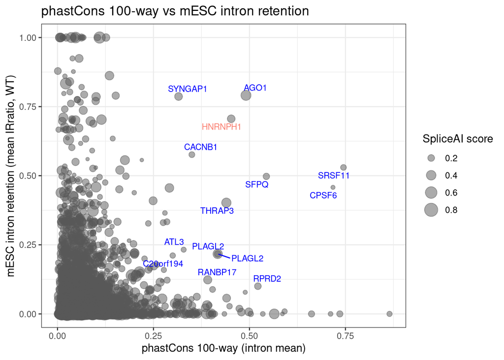

```r
library(ggrepel)

plot_df_mesc <- merged[site_class == "decoy" & !is.na(mESC_IRratio_mean) & !is.na(GENE)]
brain_label_min <- max(1L, as.integer(ceiling(50 * length(brain_cols) / length(psi_num))))

plot_phastcons_y <- function(
  df,
  y_col,
  y_label,
  x_col,
  x_label,
  title,
  label_y_min = NULL,
  label_y_max = NULL
) {
  plot_data <- df[!is.na(get(x_col)) & !is.na(get(y_col))]
  label_plot <- plot_data[
    SpliceAI_score > 0.1 &
      !is.na(SpliceAI_score) &
      get(x_col) > 0.3
  ]
  if (!is.null(label_y_min)) {
    label_plot <- label_plot[get(y_col) >= label_y_min]
  }
  if (!is.null(label_y_max)) {
    label_plot <- label_plot[get(y_col) <= label_y_max]
  }
  label_plot <- label_plot[order(-get(y_col), -SpliceAI_score)][1:min(15L, .N)]
  if (nrow(label_plot) > 0) {
    label_plot[, label_color := ifelse(grepl("^HNRNP", GENE, ignore.case = TRUE), "salmon", "blue")]
  }

  ggplot(plot_data, aes(x = .data[[x_col]], y = .data[[y_col]], size = SpliceAI_score)) +
    geom_point(alpha = 0.5, color = "grey35") +
    geom_text_repel(
      data = label_plot,
      aes(label = GENE, color = label_color),
      size = 3,
      max.overlaps = Inf,
      show.legend = FALSE
    ) +
    scale_color_identity() +
    labs(
      title = title,
      x = x_label,
      y = y_label,
      size = "SpliceAI score"
    ) +
    theme_bw()
}

p_mesc_ph100 <- plot_phastcons_y(
  plot_df_mesc,
  "mESC_IRratio_mean",
  "mESC intron retention (mean IRratio, WT)",
  "phastCons100_mean",
  "phastCons 100-way (intron mean)",
  "phastCons 100-way vs mESC intron retention",
  label_y_min = 0.1
)
p_mesc_ph470 <- plot_phastcons_y(
  plot_df_mesc,
  "mESC_IRratio_mean",
  "mESC intron retention (mean IRratio, WT)",
  "phastCons470_mean",
  "phastCons 470-way (intron mean)",
  "phastCons 470-way vs mESC intron retention",
  label_y_min = 0.1
)

print(p_mesc_ph100)
```

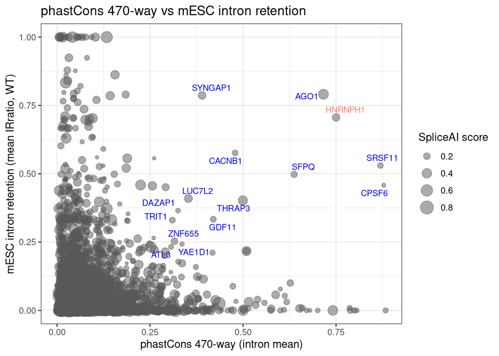

```r
print(p_mesc_ph470)
```

```r
ggsave(file.path("../figures/phastCons470_vs_mesc_ir_retention.pdf"), p_mesc_ph470, width = 8, height = 6)
```

## Plot: phastCons vs Brain tissues with PSI > 10

Only decoys retained (PSI >= 10) in at least three Vast-DB samples with `sample_group == Brain`. Y-axis counts Brain tissues only.

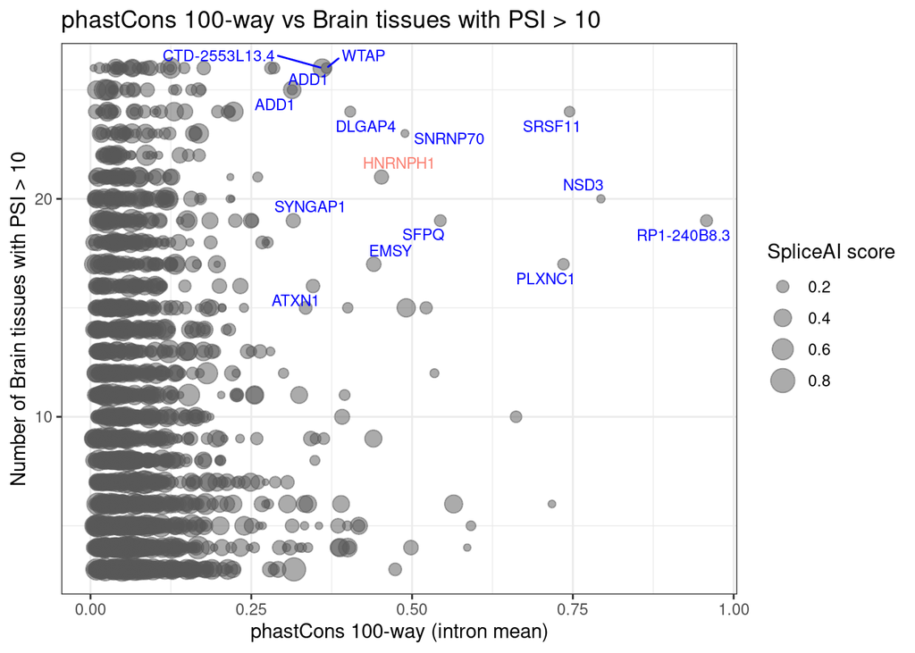

```r
plot_df_brain <- merged[
  site_class == "decoy" & brain_retained == TRUE & !is.na(psi_count_ge10_brain) & !is.na(GENE)
]

p_brain_ph100 <- plot_phastcons_y(
  plot_df_brain,
  "psi_count_ge10_brain",
  "Number of Brain tissues with PSI > 10",
  "phastCons100_mean",
  "phastCons 100-way (intron mean)",
  "phastCons 100-way vs Brain tissues with PSI > 10",
  label_y_min = brain_label_min
)
p_brain_ph470 <- plot_phastcons_y(
  plot_df_brain,
  "psi_count_ge10_brain",
  "Number of Brain tissues with PSI > 10",
  "phastCons470_mean",
  "phastCons 470-way (intron mean)",
  "phastCons 470-way vs Brain tissues with PSI > 10",
  label_y_min = brain_label_min
)

print(p_brain_ph100)
```

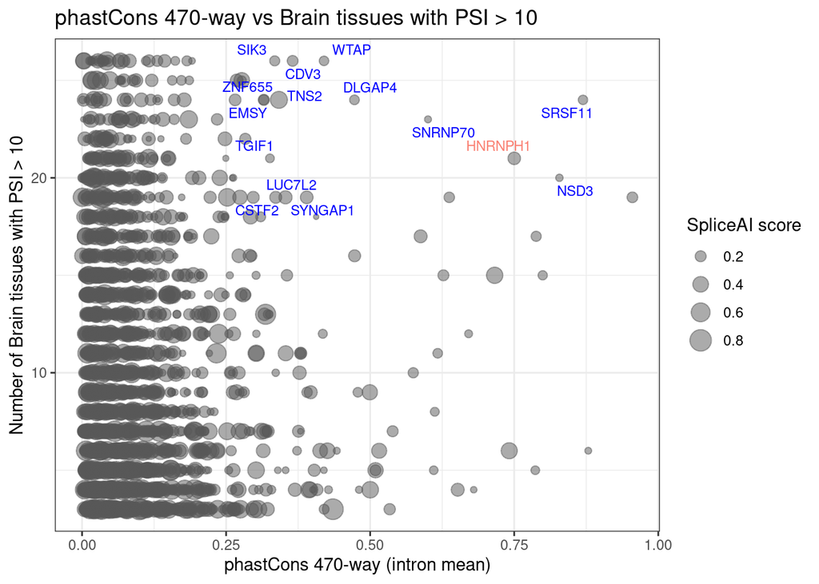

```r
print(p_brain_ph470)
```

```r
ggsave(file.path("../figures/phastCons470_vs_brain_psi.pdf"), p_brain_ph470, width = 8, height = 6)
```

## Plot: phastCons vs ALL Vast-DB tissues with PSI > 10

No tissue restriction and no `brain_retained` filter - every decoy with a phastCons value and a gene symbol is plotted. The y-axis counts **all** Vast-DB sample columns with PSI >= 10 (`psi_count_ge10`), so it spans the full tissue panel rather than the Brain subset above.

```r
plot_df_all <- merged[site_class == "decoy" & !is.na(psi_count_ge10) & !is.na(GENE)]

# Label threshold scaled to the full panel, matching how brain_label_min is
# derived for the Brain subset (top ~50 of the panel by tissue count).
all_label_min <- max(1L, as.integer(ceiling(0.5 * max(plot_df_all$psi_count_ge10, na.rm = TRUE))))

cat("All-tissue plot: ", nrow(plot_df_all), " decoys across ",
    length(psi_num), " Vast-DB sample columns\n", sep = "")
```

```
## All-tissue plot: 5679 decoys across 145 Vast-DB sample columns
```

```r
cat("  label threshold (psi_count_ge10 >= ): ", all_label_min, "\n", sep = "")
```

```
##   label threshold (psi_count_ge10 >= ): 73
```

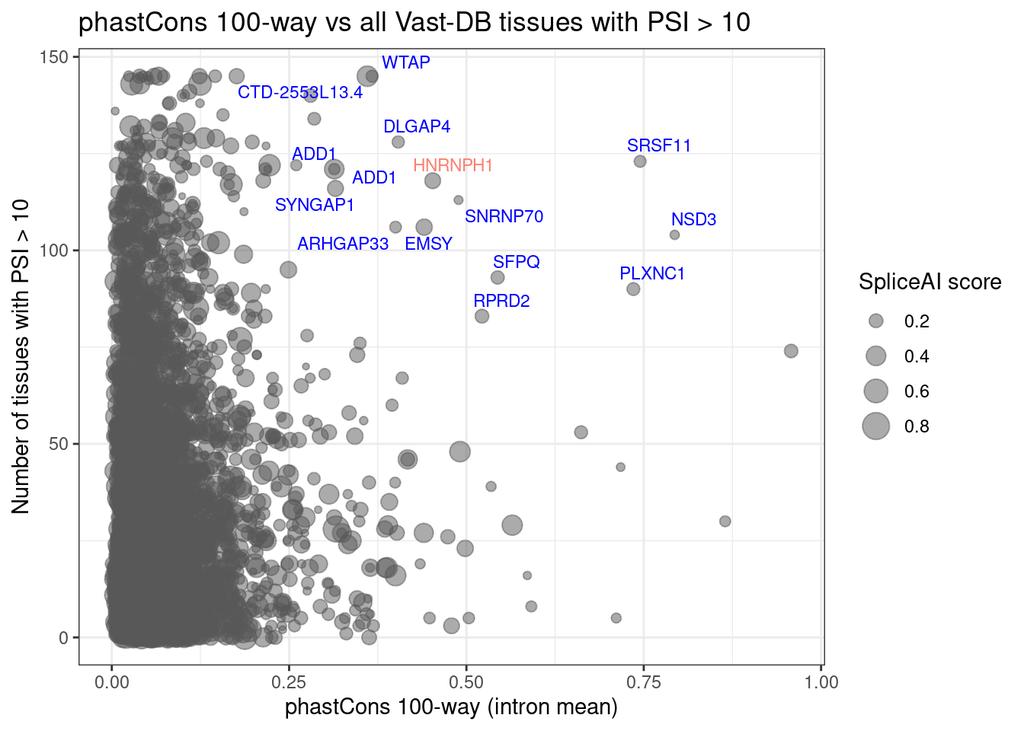

```r
p_all_ph100 <- plot_phastcons_y(
  plot_df_all,
  "psi_count_ge10",
  "Number of tissues with PSI > 10",
  "phastCons100_mean",
  "phastCons 100-way (intron mean)",
  "phastCons 100-way vs all Vast-DB tissues with PSI > 10",
  label_y_min = all_label_min
)
p_all_ph470 <- plot_phastcons_y(
  plot_df_all,
  "psi_count_ge10",
  "Number of tissues with PSI > 10",
  "phastCons470_mean",
  "phastCons 470-way (intron mean)",
  "phastCons 470-way vs all Vast-DB tissues with PSI > 10",
  label_y_min = all_label_min
)

print(p_all_ph100)
```

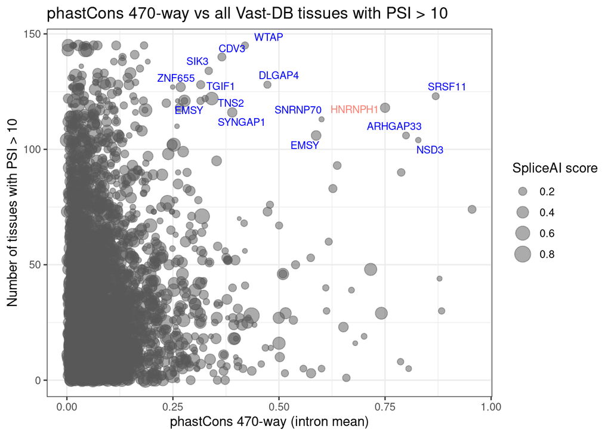

```r
print(p_all_ph470)
```

```r
dir.create("../figures", showWarnings = FALSE, recursive = TRUE)
ggsave(file.path("../figures/phastCons100_vs_all_tissue_psi.pdf"), p_all_ph100, width = 8, height = 6)
ggsave(file.path("../figures/phastCons470_vs_all_tissue_psi.pdf"), p_all_ph470, width = 8, height = 6)
```

## Plot: supported cryptics — phastCons vs ALL Vast-DB tissues with PSI > 10

The same two plots as above, for the supported cryptics: sites with no RBPnet, PRPF8 or SmB support at the site, whose intron’s canonical 5’ splice site is supported by RBPnet, PRPF8 or SmB.

```r
plot_df_cryp <- merged[site_class == "cryptic_supported" & !is.na(psi_count_ge10) & !is.na(GENE)]
if (nrow(plot_df_cryp) == 0) stop("No supported cryptics with a PSI count and gene symbol to plot.")

cryp_label_min <- max(1L, as.integer(ceiling(0.5 * max(plot_df_cryp$psi_count_ge10, na.rm = TRUE))))
cat("Supported-cryptic plot: ", nrow(plot_df_cryp), " sites across ",
    length(psi_num), " Vast-DB sample columns\n", sep = "")
```

```
## Supported-cryptic plot: 16295 sites across 145 Vast-DB sample columns
```

```r
cat("  label threshold (psi_count_ge10 >= ): ", cryp_label_min, "\n", sep = "")
```

```
##   label threshold (psi_count_ge10 >= ): 73
```

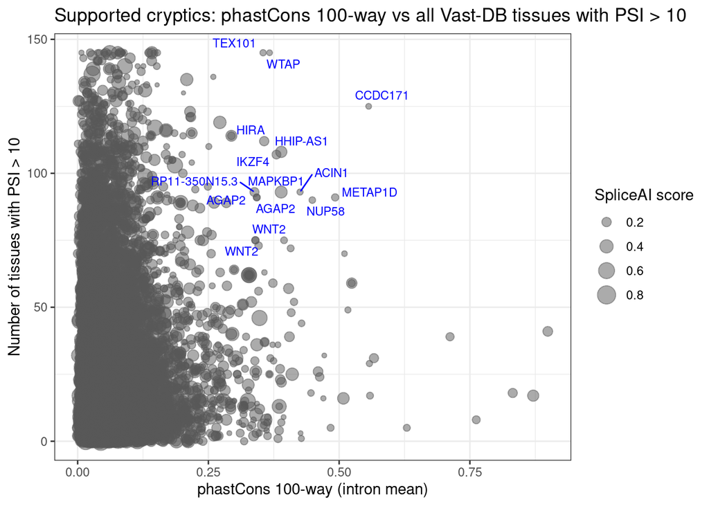

```r
p_cryp_ph100 <- plot_phastcons_y(
  plot_df_cryp,
  "psi_count_ge10",
  "Number of tissues with PSI > 10",
  "phastCons100_mean",
  "phastCons 100-way (intron mean)",
  "Supported cryptics: phastCons 100-way vs all Vast-DB tissues with PSI > 10",
  label_y_min = cryp_label_min
)
p_cryp_ph470 <- plot_phastcons_y(
  plot_df_cryp,
  "psi_count_ge10",
  "Number of tissues with PSI > 10",
  "phastCons470_mean",
  "phastCons 470-way (intron mean)",
  "Supported cryptics: phastCons 470-way vs all Vast-DB tissues with PSI > 10",
  label_y_min = cryp_label_min
)

print(p_cryp_ph100)
```

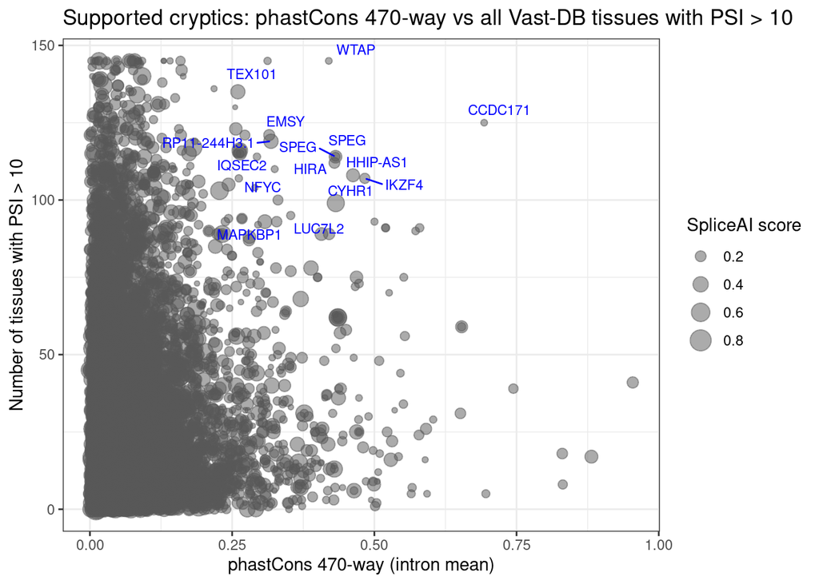

```r
print(p_cryp_ph470)
```

```r
ggsave(file.path("../figures/phastCons100_vs_all_tissue_psi_cryptics_supported.pdf"), p_cryp_ph100, width = 8, height = 6)
ggsave(file.path("../figures/phastCons470_vs_all_tissue_psi_cryptics_supported.pdf"), p_cryp_ph470, width = 8, height = 6)
```

## Export: mESC liftOver plot table (all IR-matched loci)

Full plotting table for all decoys with a matched mESC `IRratio` after hg38→mm10 liftOver and IRFinder overlap. Use hg38 `phastCons*_mean` with `mESC_IRratio_mean` for mESC IR plots; mm10 coordinates are in `mESC_lift_*` and `mESC_ir_*`.

```r
candidates <- fread("../results/decoy_IR_candidates_mouse_brain.tsv")[, .(candidate_group, decoyID)]
plot_export <- merge(
  merged[site_class == "decoy" & !is.na(mESC_IRratio_mean)],
  candidates,
  by = "decoyID",
  all.x = TRUE
)
plot_cols <- c(
  "candidate_group", "GENE", "EVENT", "COORD", "intron_length", "chr", "strand",
  "decoyID", "start", "end", "decoy_coord_1based", "decoy_distance_from_canonical_5ss",
  "intron_start", "intron_end",
  "mESC_lift_Chr", "mESC_lift_Start", "mESC_lift_End",
  "mESC_ir_Chr", "mESC_ir_Start", "mESC_ir_End", "mESC_ir_gene",
  "mESC_IRratio_mean", "mESC_IR_overlap_bp",
  "psi_count_ge10", "psi_count_ge10_brain", "brain_retained",
  "SpliceAI_score", "phastCons100_mean", "phastCons470_mean",
  "MaxEnt_decoy", "MaxEnt_canonical"
)
plot_cols <- plot_cols[plot_cols %in% names(plot_export)]
mesc_plot_tsv <- file.path(out_dir, "decoy_intron_mesc_liftover_plot_table.tsv")
fwrite(plot_export[, ..plot_cols], mesc_plot_tsv, sep = "\t", quote = FALSE)
cat(
  "Wrote mESC plot table:", mesc_plot_tsv,
  " rows:", nrow(plot_export), "\n",
  sep = ""
)
```

```
## Wrote mESC plot table:../results/decoy_intron_mesc_liftover_plot_table.tsv rows:5446
```

## Export: IR candidate coordinates (12 highlighted genes)

```r
candidates <- fread("../results/decoy_IR_candidates_mouse_brain.tsv")[, .(candidate_group, decoyID)]
candidate_ids <- candidates[, decoyID]
export_dt <- merged[decoyID %in% candidate_ids]
export_dt[, brain_tissues_PSI_ge10 := apply(
  .SD, 1,
  function(v) paste(brain_cols[!is.na(v) & v >= 10], collapse = ";")
), .SDcols = brain_cols]

export_cols <- c(
  "candidate_group", "GENE", "EVENT", "COORD", "intron_length", "chr", "strand",
  "decoyID", "start", "end", "decoy_coord_1based", "decoy_distance_from_canonical_5ss",
  "intron_start", "intron_end",
  "mESC_lift_Chr", "mESC_lift_Start", "mESC_lift_End",
  "mESC_ir_Chr", "mESC_ir_Start", "mESC_ir_End", "mESC_ir_gene",
  "mESC_IRratio_mean", "mESC_IR_overlap_bp",
  "psi_count_ge10", "psi_count_ge10_brain", "brain_retained", "brain_tissues_PSI_ge10",
  "SpliceAI_score", "phastCons100_mean", "phastCons470_mean",
  "MaxEnt_decoy", "MaxEnt_canonical"
)
export_dt <- merge(candidates, export_dt, by = "decoyID", all.x = TRUE)
export_cols <- export_cols[export_cols %in% names(export_dt)]
candidate_export_tsv <- file.path(out_dir, "decoy_IRfinder_mESCliftover.tsv")
fwrite(export_dt[, ..export_cols], candidate_export_tsv, sep = "\t", quote = FALSE)
cat("Wrote candidate export:", candidate_export_tsv, " rows:", nrow(export_dt), "\n")
```

```
## Wrote candidate export: ../results/decoy_IRfinder_mESCliftover.tsv  rows: 12
```

## Decoys vs supported cryptics: per-class summary and comparison figure

Every feature is computed the same way for both classes, so they can be compared directly. The summary gives n, median and IQR per class; the figure shows the distributions side by side.

```r
compare_feats <- c(
  "psi_count_ge10", "psi_count_ge10_brain", "intron_length", "intron_gc", "site_gc_49nt",
  "SpliceAI_score", "decoy_distance_from_canonical_5ss",
  "MaxEnt_decoy", "MaxEnt_canonical", "phastCons100_mean", "phastCons470_mean"
)
compare_feats <- compare_feats[compare_feats %in% names(merged)]

class_summary <- merged[, .(
  n = .N,
  brain_retained_n = sum(brain_retained, na.rm = TRUE)
), by = site_class]
for (f in compare_feats) {
  q <- merged[, .(
    med = median(get(f), na.rm = TRUE),
    q1 = quantile(get(f), 0.25, na.rm = TRUE, names = FALSE),
    q3 = quantile(get(f), 0.75, na.rm = TRUE, names = FALSE),
    n_na = sum(is.na(get(f)))
  ), by = site_class]
  setnames(q, c("med", "q1", "q3", "n_na"), paste0(f, c("_median", "_q1", "_q3", "_na")))
  class_summary <- merge(class_summary, q, by = "site_class")
}
fwrite(class_summary, class_summary_tsv, sep = "\t", quote = FALSE)
cat("Wrote per-class summary:", class_summary_tsv, "\n")
```

```
## Wrote per-class summary: ../results/decoy_vs_cryptic_class_summary.tsv
```

```r
print(class_summary[, c("site_class", "n", grep("_median$", names(class_summary), value = TRUE)), with = FALSE])
```

```
## Key: <site_class>
##           site_class     n psi_count_ge10_median psi_count_ge10_brain_median
##               <char> <int>                 <num>                       <num>
## 1: cryptic_supported 16295                    18                           3
## 2:             decoy  5679                    20                           3
##    intron_length_median intron_gc_median site_gc_49nt_median
##                   <int>            <num>               <num>
## 1:                 3453         0.464390            0.489796
## 2:                 3091         0.416667            0.448980
##    SpliceAI_score_median decoy_distance_from_canonical_5ss_median
##                    <num>                                    <int>
## 1:              0.163639                                     1433
## 2:              0.192391                                     1185
##    MaxEnt_decoy_median MaxEnt_canonical_median phastCons100_mean_median
##                  <num>                   <num>                    <num>
## 1:                8.72                    8.98                0.0433328
## 2:                9.60                    8.73                0.0495493
##    phastCons470_mean_median
##                       <num>
## 1:                0.0454934
## 2:                0.0555461
```

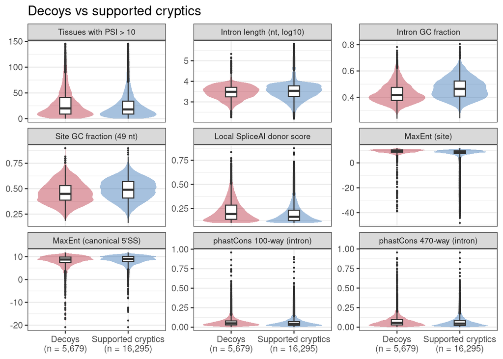

```r
plot_feats <- c(
  psi_count_ge10 = "Tissues with PSI > 10",
  intron_length = "Intron length (nt, log10)",
  intron_gc = "Intron GC fraction",
  site_gc_49nt = "Site GC fraction (49 nt)",
  SpliceAI_score = "Local SpliceAI donor score",
  MaxEnt_decoy = "MaxEnt (site)",
  MaxEnt_canonical = "MaxEnt (canonical 5'SS)",
  phastCons100_mean = "phastCons 100-way (intron)",
  phastCons470_mean = "phastCons 470-way (intron)"
)
plot_feats <- plot_feats[names(plot_feats) %in% names(merged)]

plot_class_comparison <- function(dt, title) {
  long <- melt(
    cbind(dt[, .(decoyID, site_class)],
          dt[, lapply(.SD, as.numeric), .SDcols = names(plot_feats)]),
    id.vars = c("decoyID", "site_class"), variable.name = "feature", value.name = "value"
  )
  long <- long[!is.na(value)]
  long[feature == "intron_length", value := log10(value)]
  long[, feature := factor(plot_feats[as.character(feature)], levels = plot_feats)]
  n_by <- dt[, .N, by = site_class]
  lab <- c(decoy = sprintf("Decoys\n(n = %s)", format(n_by[site_class == "decoy", N], big.mark = ",")),
           cryptic_supported = sprintf("Supported cryptics\n(n = %s)", format(n_by[site_class == "cryptic_supported", N], big.mark = ",")))
  long[, site_class := factor(lab[as.character(site_class)], levels = lab)]
  ggplot(long, aes(x = site_class, y = value, fill = site_class)) +
    geom_violin(colour = NA, alpha = 0.4, scale = "width") +
    geom_boxplot(width = 0.18, outlier.size = 0.3, fill = "white") +
    facet_wrap(~ feature, scales = "free_y", ncol = 3) +
    scale_fill_manual(values = setNames(c("#B2182B", "#2166AC"), lab)) +
    labs(x = NULL, y = NULL, title = title) +
    theme_bw() +
    theme(legend.position = "none", strip.text = element_text(size = 8))
}

p_class <- plot_class_comparison(merged, "Decoys vs supported cryptics")
print(p_class)
```

```r
dir.create("../figures", showWarnings = FALSE, recursive = TRUE)
ggsave("../figures/decoy_vs_cryptic_class_comparison.pdf", p_class, width = 9, height = 9)
```

## MaxEntScan thresholds

Both classes filtered to a site MaxEnt score of at least 8, 9 or 10; the class comparison figure is redrawn on the filtered sites and the counts are tabulated.

```r
maxent_thresholds <- c(8, 9, 10)
maxent_counts <- rbindlist(lapply(maxent_thresholds, function(thr) {
  keep <- merged[!is.na(MaxEnt_decoy) & MaxEnt_decoy >= thr]
  p <- plot_class_comparison(keep, sprintf("Decoys vs supported cryptics, site MaxEnt >= %d", thr))
  ggsave(sprintf("../figures/decoy_vs_cryptic_class_comparison_maxent%d.pdf", thr), p, width = 9, height = 9)
  keep[, .(threshold = thr, n = .N,
           median_tissues_psi10 = as.numeric(median(psi_count_ge10)),
           hnrnph1_kept = any(decoyID == "HNRNPH1_179620582")), by = site_class]
}))
all_counts <- merged[, .(threshold = 0, n = .N, median_tissues_psi10 = as.numeric(median(psi_count_ge10)),
                         hnrnph1_kept = any(decoyID == "HNRNPH1_179620582")), by = site_class]
maxent_counts <- rbind(all_counts, maxent_counts)[order(site_class, threshold)]
print(maxent_counts)
```

```
##           site_class threshold     n median_tissues_psi10 hnrnph1_kept
##               <char>     <num> <int>                <num>       <lgcl>
## 1: cryptic_supported         0 16295                   18        FALSE
## 2: cryptic_supported         8 10998                   18        FALSE
## 3: cryptic_supported         9  7000                   18        FALSE
## 4: cryptic_supported        10  3418                   18        FALSE
## 5:             decoy         0  5679                   20         TRUE
## 6:             decoy         8  4768                   21         TRUE
## 7:             decoy         9  3563                   21         TRUE
## 8:             decoy        10  2200                   22         TRUE
```

```r
fwrite(maxent_counts, file.path(out_dir, "maxent_threshold_counts.tsv"), sep = "\t", quote = FALSE)
```

# Part 5 — Recount junction support

Whether each site is used as a 5’ splice site in RNA-seq junction data, from the Snaptron/Recount compilations (`tcgav2`, `srav3h`, `gtexv2`). `scripts/query_recount_junctions.py` (run on the cluster by `scripts/slurm_query_recount.sh`) reports every junction whose boundary lies within 5 bp of a site, annotated or not. Here a junction counts as using the site as its 5’ splice site when its donor boundary is the first intronic base after the site and it has at least 5 reads. A site with an unannotated junction is a cryptic 5’ splice site that is used in some samples; an annotated junction means the site is a known donor. No site is removed at this step; the columns are added to the feature table so the classes can be compared.

```r
# A junction supports a site as a 5' splice site when its donor-side boundary is the first intronic base
# after the site (junction start = site + 1 on +, junction end = site - 1 on -) and it has at least
# MIN_READS reads summed over the compilation's samples.
MIN_READS <- 5L
recount_files <- Sys.glob(file.path(out_dir, "recount_*_junctions.tsv"))
recount_cols <- c("recount_compilations", "recount_5ss_junctions", "recount_annotated", "recount_unannotated",
                  "recount_unannotated_samples", "recount_unannotated_reads")
if (length(recount_files) == 0) {
  cat("Note: no results/recount_*_junctions.tsv found - Recount junction support not merged.\n",
      "  Generate with scripts/slurm_query_recount.sh (see README, Recount junction support).\n")
  merged[, (recount_cols) := list(0L, 0L, FALSE, FALSE, 0L, 0L)]
  merged[, recount_support := NA_character_]
} else {
  rj <- rbindlist(lapply(recount_files, fread, sep = "\t",
                         select = c("compilation", "site_id", "strand", "snaptron_id", "annotated",
                                    "samples_count", "coverage_sum", "start_offset", "end_offset")))
  rj[, donor_offset := fifelse(strand == "+", start_offset, -end_offset)]
  cat("Recount compilations:", paste(sort(unique(rj$compilation)), collapse = ", "), " junction rows:", nrow(rj), "\n")
  cat("Donor-side offset of junction boundaries (1 = first intronic base after the site):\n")
  print(rj[donor_offset %between% c(-5, 5), .N, by = donor_offset][order(donor_offset)])
  use <- rj[donor_offset == 1L & coverage_sum >= MIN_READS]
  rc_site <- use[, .(
    recount_compilations = uniqueN(compilation),
    recount_5ss_junctions = .N,
    recount_annotated = any(annotated == 1L),
    recount_unannotated = any(annotated == 0L),
    recount_unannotated_samples = as.integer(max(c(0L, samples_count[annotated == 0L]))),
    recount_unannotated_reads = as.integer(max(c(0L, coverage_sum[annotated == 0L])))
  ), by = .(decoyID = site_id)]
  merged <- merge(merged, rc_site, by = "decoyID", all.x = TRUE)
  merged[is.na(recount_compilations), (recount_cols) := list(0L, 0L, FALSE, FALSE, 0L, 0L)]
  # annotated: an annotated junction uses the site as its donor (a known donor in some annotation);
  # unannotated_only: only unannotated junctions do (a cryptic donor used in RNA-seq); no_junction: neither.
  merged[, recount_support := fifelse(recount_annotated, "annotated",
                               fifelse(recount_unannotated, "unannotated_only", "no_junction"))]
  cat("\nRecount 5'SS junction support by site class (>=", MIN_READS, "reads, exact donor boundary):\n")
  tab <- dcast(merged[, .N, by = .(site_class, recount_support)], site_class ~ recount_support, value.var = "N", fill = 0L)
  print(tab)
  print(merged[, .(annotated = mean(recount_support == "annotated"), unannotated_only = mean(recount_support == "unannotated_only"),
                   no_junction = mean(recount_support == "no_junction")), by = site_class])
  cat("\nUnannotated-only sites by number of compilations supporting them:\n")
  print(merged[recount_support == "unannotated_only", .N, by = .(site_class, recount_compilations)][order(site_class, recount_compilations)])
  cat("\nHNRNPH1_179620582:\n")
  print(merged[decoyID == "HNRNPH1_179620582", .(recount_support, recount_compilations, recount_5ss_junctions,
                                                   recount_unannotated_samples, recount_unannotated_reads)])
}
```

[output not shown]

## Donor usage: predicted sites vs Vast-DB alternative 5’ splice sites

Reads through each site used as a 5’ splice site, summed over its junctions (exact donor boundary, junctions with at least `MIN_READS` reads), for the final decoys and supported cryptics and for every donor of the Vast-DB alternative 5’ splice site events (`results/recount_altd_<compilation>_junctions.tsv`, from `scripts/make_altd_donor_beds.py` and `scripts/slurm_query_recount.sh` with `OUT_TAG=recount_altd`). Reference donors are each event’s first-listed option; alternative donors are the others. Sites with no qualifying junction are left off the log axis; their share is noted in each panel.

```
##     compilation        site_class sites with_junction median_reads_if_used
##          <char>            <fctr> <int>         <num>                <num>
##  1:      gtexv2             decoy  5679     0.8270822                163.0
##  2:      gtexv2 cryptic_supported 16295     0.7050629                 93.0
##  3:      gtexv2  altd_alternative 77349     0.8701082               2120.5
##  4:      gtexv2    altd_reference 55993     0.9056846              13006.0
##  5:      srav3h             decoy  5679     0.9508716                819.0
##  6:      srav3h cryptic_supported 16295     0.8658484                344.0
##  7:      srav3h  altd_alternative 77349     0.9278465              10078.5
##  8:      srav3h    altd_reference 55993     0.9600843              55749.0
##  9:      tcgav2             decoy  5679     0.7076950                 79.0
## 10:      tcgav2 cryptic_supported 16295     0.5736729                 51.0
## 11:      tcgav2  altd_alternative 77349     0.8369856                935.0
## 12:      tcgav2    altd_reference 55993     0.8860215               6269.0
##     median_reads_all
##                <num>
##  1:               80
##  2:               28
##  3:             1169
##  4:             6692
##  5:              686
##  6:              211
##  7:             7396
##  8:            42480
##  9:               25
## 10:                8
## 11:              423
## 12:             2665
```

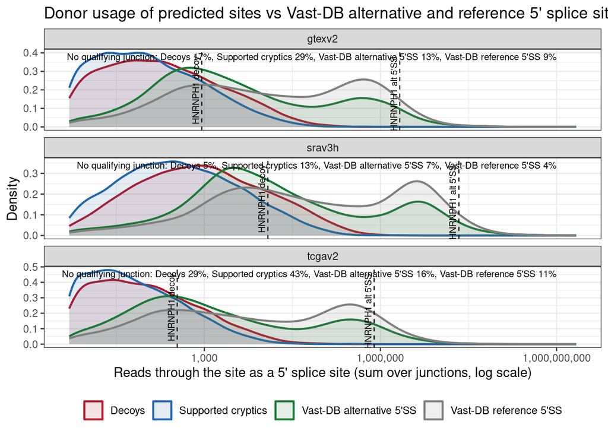

```
##
## Share of sites with no qualifying junction (legend values):
## Key: <site_class>
##           site_class    gtexv2    srav3h   tcgav2
##               <fctr>     <num>     <num>    <num>
## 1:             decoy 17.291777  4.912837 29.23050
## 2: cryptic_supported 29.493710 13.415158 42.63271
## 3:  altd_alternative 12.989179  7.215349 16.30144
## 4:    altd_reference  9.431536  3.991570 11.39785
##
## HNRNPH1 decoy and alternative 5'SS donor reads:
## Key: <what>
##                what  gtexv2   srav3h tcgav2
##              <char>   <num>    <num>  <num>
## 1: HNRNPH1 alt 5'SS 2136903 21729345 781155
## 2:    HNRNPH1 decoy     906    12110    345
```

```r
altd_files <- Sys.glob(file.path(out_dir, "recount_altd_*_junctions.tsv"))
site_files <- setdiff(Sys.glob(file.path(out_dir, "recount_*_junctions.tsv")), altd_files)
if (length(altd_files) == 0 || length(site_files) == 0) {
  cat("Note: Recount junction tables for the sites and/or the alternative 5' splice sites are missing - usage distribution skipped.\n")
} else {
  jcols <- c("compilation", "site_id", "site_class", "strand", "coverage_sum", "samples_count", "start_offset", "end_offset")
  donor_use <- function(files) {
    j <- rbindlist(lapply(files, fread, sep = "\t", select = jcols))
    j <- j[fifelse(strand == "+", start_offset, -end_offset) == 1L & coverage_sum >= MIN_READS]
    j[, .(donor_reads = sum(as.numeric(coverage_sum)), max_samples = max(samples_count)), by = .(compilation, site_id, site_class)]
  }
  use <- rbind(donor_use(site_files), donor_use(altd_files))
  comps <- sort(unique(use$compilation))

  # Every site, including those with no qualifying junction.
  read_ids <- function(path, cls) {
    b <- fread(path, sep = "\t", header = FALSE, select = c(2, 4))
    data.table(site_id = paste0(b$V4, "_", b$V2), site_class = cls)
  }
  all_sites <- rbind(
    merged[, .(site_id = decoyID, site_class)],
    read_ids(file.path(out_dir, "altd_donors_reference.bed"), "altd_reference"),
    read_ids(file.path(out_dir, "altd_donors_alternative.bed"), "altd_alternative")
  )
  grid <- all_sites[, .(compilation = comps), by = .(site_id, site_class)]
  use <- merge(grid, use[, .(compilation, site_id, donor_reads, max_samples)], by = c("compilation", "site_id"), all.x = TRUE)
  use[is.na(donor_reads), `:=`(donor_reads = 0, max_samples = 0L)]

  grp_levels <- c("decoy", "cryptic_supported", "altd_alternative", "altd_reference")
  grp_label <- c(decoy = "Decoys", cryptic_supported = "Supported cryptics",
                 altd_alternative = "Vast-DB alternative 5'SS", altd_reference = "Vast-DB reference 5'SS")
  grp_color <- c(decoy = "#B2182B", cryptic_supported = "#2166AC", altd_alternative = "#1B7837", altd_reference = "#7F7F7F")
  use[, site_class := factor(site_class, levels = grp_levels)]

  usage_summary <- use[, .(sites = .N, with_junction = mean(donor_reads > 0),
                           median_reads_if_used = as.numeric(median(donor_reads[donor_reads > 0])),
                           median_reads_all = as.numeric(median(donor_reads))), by = .(compilation, site_class)][order(compilation, site_class)]
  print(usage_summary)
  fwrite(usage_summary, file.path(out_dir, "recount_donor_usage_summary.tsv"), sep = "\t", quote = FALSE)

  lab <- use[, .(pct_none = 100 * mean(donor_reads == 0)), by = .(compilation, site_class)]
  note <- lab[order(site_class), .(note = paste0("No qualifying junction: ",
                                                paste(sprintf("%s %.0f%%", grp_label[as.character(site_class)], pct_none), collapse = ", "))),
              by = compilation]
  pdat <- use[donor_reads > 0]
  marks <- use[site_id %in% c("HNRNPH1_179620582", "HNRNPH1|HsaALTD0003092-2/5_179623594")]
  marks[, what := fifelse(site_id == "HNRNPH1_179620582", "HNRNPH1 decoy", "HNRNPH1 alt 5'SS")]

  p_use <- ggplot(pdat, aes(x = donor_reads, colour = site_class)) +
    geom_density(aes(fill = site_class), alpha = 0.12, linewidth = 0.8, adjust = 1.2) +
    geom_vline(data = marks[donor_reads > 0], aes(xintercept = donor_reads), linetype = "dashed", linewidth = 0.4) +
    geom_text(data = marks[donor_reads > 0], aes(x = donor_reads, y = Inf, label = what), angle = 90,
              vjust = -0.4, hjust = 1.1, size = 2.6, inherit.aes = FALSE) +
    geom_text(data = note, aes(x = 1e9, y = Inf, label = note), hjust = 1, vjust = 1.6, size = 2.7, inherit.aes = FALSE) +
    scale_x_log10(labels = scales::label_comma()) +
    scale_colour_manual(values = grp_color, labels = grp_label, name = NULL) +
    scale_fill_manual(values = grp_color, labels = grp_label, name = NULL) +
    facet_wrap(~ compilation, ncol = 1, scales = "free_y") +
    labs(x = "Reads through the site as a 5' splice site (sum over junctions, log scale)", y = "Density",
         title = "Donor usage of predicted sites vs Vast-DB alternative and reference 5' splice sites") +
    theme_bw() + theme(legend.position = "bottom")
  print(p_use)
  ggsave("../figures/recount_donor_usage_distribution.pdf", p_use, width = 9, height = 10)

  cat("\nShare of sites with no qualifying junction (legend values):\n")
  print(dcast(lab, site_class ~ compilation, value.var = "pct_none"))
  cat("\nHNRNPH1 decoy and alternative 5'SS donor reads:\n")
  print(dcast(marks, what ~ compilation, value.var = "donor_reads"))
}
```

```r
fwrite(merged, final_tsv, sep = "\t", quote = FALSE)
cat("Final table:", final_tsv, " rows:", nrow(merged), " (",
    paste(merged[, .N, by = site_class][, paste0(site_class, "=", N)], collapse = ", "), ")\n")
```

```
## Final table: ../results/decoy_intron_features_final.tsv  rows: 21974  ( decoy=5679, cryptic_supported=16295 )
```